# Beyond Normalizations: Incorporating Scale Uncertainty in ALDEx2

November 10, 2023

## Setup and Code Availability

- The newest version of ALDEx2 is necessary for this workshop (version 1.35.0, updated October 2023) . Available on Bioconductor or GitHub (https://github.com/ggloor/ALDEx_bioc).

```r
##To install from Bioconductor:
BiocManager::install("ALDEx2")

##To install from GitHub:
devtools::install_github("ggloor/ALDEx_bioc")
```

## Sequence Count Data

We are considering data that was collected by high-throughput sequencing (HTS) technologies.

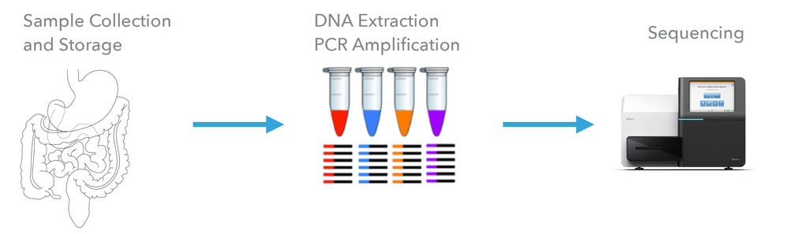

**Sample-to-sample variation is driven by this process rather than biology.**

## Notation

- \(W\): A \(D \times N\) table of true counts in the underlying system where \(D\) is the number of taxa/species/etc. and \(N\) is the number of samples.
- \(Y\): A \(D \times N\) table of sampled data where \(D\) is the number of taxa/species/etc. and \(N\) is the number of samples.
- \(X\): A \(Q \times N\) table of covariates where \(Q\) is the number of variables of interest.

**\(W\) is the true table of counts (e.g., actual counts in the stomach) whereas \(Y\) is the sampled counts.**

## Data Simulation

Consider a simple simulation studying the microbiome pre/post antibiotic administration:

- 2 conditions (pre- and post- administration) with 50 samples per condition
- 20 taxa: 4 change between conditions, 16 don’t

To simulate the data, we:

1. Use the Poisson distribution to sample true abundances (\(W\)).
2. Use Multinomial sampling to sub-sample \(W\) to an arbitrary sequencing depth (\(Y\)).

Simulation functions can be found in scripts > data_simulation.R.

## Reading in the Simulated Data

```r
###Analysis file for simulated data
library(ALDEx2)
library(tidyverse)
library(ggplot2)
library(ggpattern)
library(cowplot)

set.seed(12345)
setwd('..')
##Reading in data (see "data_simulation.R" for details.)
rdat <- read.csv(file.path("data/simulation/sim_seq_dat.csv"))
flow_data <- read.csv(file.path("data/simulation/sim_flow_dat.csv"))
```

## Inspecting the Data

```r
## "Y" represents the OTU table
Y <- t(rdat[,-1])
Y[1:4,1:4]
```

```
##       [,1] [,2] [,3] [,4]
## Taxa1  657  672  652  676
## Taxa2  669  697  634  652
## Taxa3  663  675  660  675
## Taxa4  666  668  633  670
```

```r
##Vector denoting whether samples was in pre- or post- antibiotic condition.
conds <- as.character(rdat[,1])
conds[c(1:4,51:55)]
```

```
## [1] "Pre"  "Pre"  "Pre"  "Pre"  "Post" "Post" "Post" "Post" "Post"
```

## Research Question

**Which taxa change in abundance after antibiotic administration?**

- This can be answered by estimating and testing log-fold change for each taxa, i.e.: \[\theta_d = \mathrm{mean}_{n:x_n = 1} \log W_{dn} - \mathrm{mean}_{n:x_n=0} \log W_{dn}.\]
- How should we analyze this data to answer the research question?

## Option 1: Categorical Data Perspective

Sequencing depth variation is *extra noise* that must be removed.

1. Data Normalizations
   - Rarefaction
   - Total Sum Scaling (converting to proportions)
   - Median of Ratios Normalization (DESeq2)
2. Parameter Normalization in Multinomial Models
   - Centered Log-Ratio Transformation (ALDEx2, SpiecEasi, Songbird)
3. Penalized Estimators (CCLasso, SparCC)

## These methods get worse with more data.

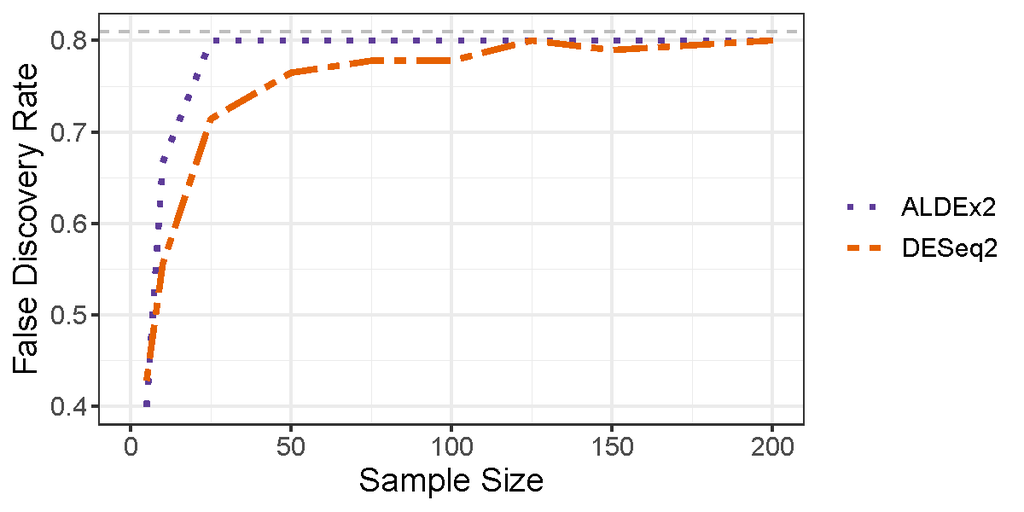

## Option 2: CoDA Perspective

- These data are compositional.
- Certain analyses (e.g., differential abundance) cannot be done rigorously.

[figure not shown]

## New Option: Scale Reliant Inference Perspective

Recently, we developed a new perspective that bridges the gap between these two approaches.

- \(Y\) is a measurement of the underlying system \(W\).
- We are trying to estimate a quantity that depends on \(W\) (i.e., \(\theta = f(W)\)). However, \(W\) depends on both the composition and system scale, i.e.:

\[W_{dn} = W_{dn}^\parallel W_n^\perp\] \[W_n^\perp = \sum_{d=1}^D W_{dn}\]

## Disconnect between Our Research Question and Common Estimators

Normalizations (Option 1) create a disconnect between the research question the actual analysis.

Consider the desired estimate of log-fold changes: \[\theta_d = \mathrm{mean}_{n:x_n = 1} \log W_{dn} - \mathrm{mean}_{n:x_n=0} \log W_{dn}.\] Normalizations return estimates of differences in *normalized* amounts:

\[\tilde{\theta}_d = \mathrm{mean}_{n:x_n = 1} \log \tilde{W}_{dn} - \mathrm{mean}_{n:x_n=0} \log \tilde{W}_{dn}.\]

**Can these two be the same?**

## Problems with Deterministic Normalizations

1. They impose some sort of modeling assumption about the system scale.
2. They are often hard to interpret.
3. They are often assumed with complete certainty.

## ALDEx2 Software Suite

ALDEx2 is a general purpose software suite that can be used to fit a wide variety of linear models (including differential abundance).

- **Step 1:** Model sampling uncertainty by drawing \(S\) samples from a Dirichlet distribution.

\[W_{\cdot i}^{\parallel (s)} \sim \mathrm{Dir}(Y_{\cdot i} + \alpha)\]

- **Step 2:** Transform these samples using the CLR.

\[\log \hat{W}_{\cdot i}^{(s)} = \log W_{\cdot i}^{\parallel (s)} - \mathrm{mean}(\log W_{\cdot i}^{\parallel (s)}) \]

## ALDEx2 Software Suite, cont.

- **Step 3:** Test for differences in log-fold changes.

\[\hat{\theta}_d^{(s)} = \mathrm{mean}_{i \in \mathrm{case}} \log \hat{W}_{di}^{(s)} - \mathrm{mean}_{i \in \mathrm{control}} \log \hat{W}_{di}^{(s)}\]

\[H_0: \hat{\theta}_d^{(s)} = 0 \, \, \, \mathrm{versus} \, \, \, H_A: \hat{\theta}_d^{(s)} \ne 0\]

- **Step 4:** Aggregate over the Monte Carlo replicates.

\[ \hat{\theta}_d = \sum_{s=1}^S \hat{\theta}_d^{(s)}\]

\[ \hat{p}_d = \sum_{s=1}^S \hat{p}_d^{(s)}\]

## Unacknowledged Bias within ALDEx2

Step 2 places an assumption on system scale.

- Consider that \(\log W_{dn} = \log W_{dn}^\parallel + \log W_n^\perp\).
- After some math, we can show that the CLR transformation in Step 2 corresponds to the assumption

\[\log W_n^\perp = - \mathrm{mean}(\log \hat{W}_{\cdot n}^\parallel).\]

**How does this affect inference?**

**Is this ever (exactly) true? Can it ever be useful?**

## The Practical Effects of Unacknowledged Bias

```r
## Fitting and analyzing the original ALDEx2
## model
mod.base <- aldex(Y, conds)
print(row.names(mod.base %>%
    filter(we.eBH < 0.05)))
```

[1] “Taxa1” “Taxa2” “Taxa3” “Taxa4” “Taxa5” “Taxa6” “Taxa7” “Taxa8” [9] “Taxa9” “Taxa10” “Taxa11” “Taxa12” “Taxa13” “Taxa14” “Taxa15” “Taxa16” [17] “Taxa17” “Taxa18” “Taxa19” “Taxa20”

**All taxa are significant! FDR of 80%!!**

## Moving Past Normalizations to Scale within ALDEx2

Rather than use the CLR or another normalization, we use a stochastic model for scale, i.e. replace Step 2:

- **Step 1:** Model sampling uncertainty by drawing \(S\) samples from a Dirichlet distribution.

\[W_{\cdot i}^{\parallel (s)} \sim \mathrm{Dir}(Y_{\cdot i} + \alpha)\]

- **Step 2:** Sample \(\log W_n^\perp \sim Q\), combine with samples from Step 1.
- **Steps 3 + 4:** As before.

## Re-creating the CLR with scale.

We can recreate the CLR with the following model:

\[Q \sim N(- \mathrm{mean}(\log \hat{W}_{\cdot n}^\parallel), 1e-3).\]

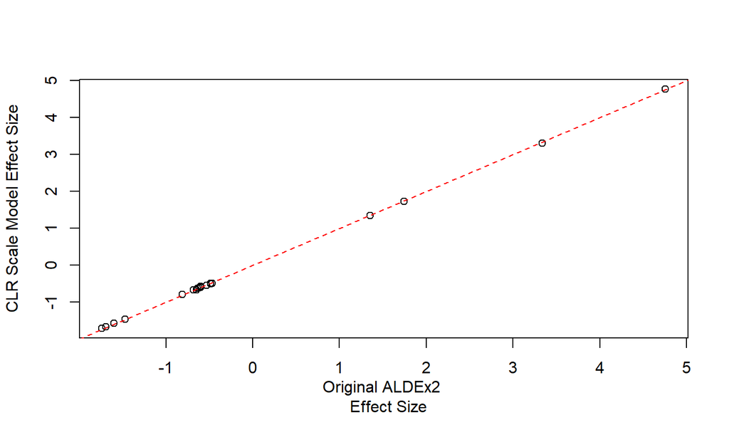

```r
mod.clr <- aldex(Y, conds, gamma = 1e-3)
plot(mod.base$effect, mod.clr$effect, xlab = "Original ALDEx2
  Effect Size", ylab = "CLR Scale Model Effect Size")
abline(a=0,b=1, col = "red", lty = "dashed")
```

## Scale Models in ALDEx2

\[\log W_n^\perp \sim Q\]

We place no restrictions on what \(Q\) can be, although there are some helpful options to consider:

1. Scale models that place errors on normalization assumptions.
2. Scale models that use outside measurements.
3. Scale models that use biological knowledge.

## New Additions to ALDEx2

## Including scale through `gamma`.

- The argument `gamma` has been added to the `aldex` and `aldex.clr` function.
- `gamma` can either be a single numeric or a matrix.
  1. Single numeric: controls the noise on the default scale model.
  2. Matrix: A \(N \times S\) matrix of samples of \(W\).

## Option 1: Default Scale Model

The default scale model is based on errors in the CLR normalization.

\[\log \hat{W}_{n}^{\perp(s)} = - \mathrm{mean} \left(\log \hat{W}^{\parallel (s)}_{\cdot n}\right) + \Lambda^\perp x_{n}\] \[\Lambda^\perp \sim \ N(0, \gamma^2).\]

## Decoding the Default Scale Model

Note that if \(\gamma \rightarrow 0\), the default scale model is equal to the normalization, i.e.,

\[\log \hat{W}_{n}^{\perp(s)} = - \mathrm{mean} \left(\log \hat{W}^{\parallel (s)}_{\cdot n}\right).\]

Thus, the noise component (\(\Lambda^\perp x_{n}\)) where \(\Lambda^\perp \sim \ N(0, \gamma^2)\) controls deviations from this assumption.

## Decoding the Default Scale Model, cont.

\[\log \hat{W}_{n}^{\perp(s)} = - \mathrm{mean} \left(\log \hat{W}^{\parallel (s)}_{\cdot n}\right) + \Lambda^\perp x_{n}\] \[\Lambda^\perp \sim \ N(0, \gamma^2).\]

- By the empirical rule, 95% of samples from \(\Lambda^\perp\) fall within \(2 \gamma\) of zero.
- This implies that, with 95% certainty, the scale of the pre-condition falls within \(2^{\pm 2 \gamma}\) of the post-condition.
- Taken with the CLR assumption, this implies that, with 95% certainty, the scales between conditions fall within the range (\(2^{\hat{\theta}^\perp-2 \gamma}, 2^{\hat{\theta}^\perp+2 \gamma}\)) where \(\hat{\theta}^\perp\) is what is implied by the CLR.

## How to Choose \(\gamma\)

We recommend a value of \(\gamma = 0.50\).

- This corresponds the the assumption that 95% of the scale samples are within \((0.5, 2)\) of the geometric mean.
- In words, 95% of the scale samples are within half or double of the amount implied by the normalization.
- **Any value of \(\gamma > 0\) is an improvement over the status quo!!**

## Option 1: Examples (Some Noise)

```r
## Adding noise via the default scale model
mod.ss <- aldex(Y, conds, gamma = .25)
mod.ss %>% filter(we.eBH < 0.05)
```

```
##          rab.all rab.win.Post rab.win.Pre  diff.btw  diff.win   effect
## Taxa4   1.746962     1.527557    2.207001 0.6853050 0.2715392 2.471074
## Taxa15 -1.444189    -1.824995   -1.064686 0.7788118 0.5294582 1.393110
## Taxa20 -1.926847    -2.786268   -1.091654 1.7237804 0.5934539 2.902773
##             overlap        we.ep       we.eBH        wi.ep       wi.eBH
## Taxa4  0.0053126904 1.767374e-08 1.767374e-07 1.168572e-07 1.168572e-06
## Taxa15 0.0531084217 5.146644e-06 3.431096e-05 2.457754e-05 1.638503e-04
## Taxa20 0.0003155441 2.274644e-24 4.548065e-23 7.454892e-18 8.059931e-17
```

**3 of 20 taxa (all true positives) are significant!**

## Option 1: Examples (More Noise)

```r
## Adding more noise via the default scale model
mod.ss.high <- aldex(Y, conds, gamma = 1)
mod.ss.high %>% filter(we.eBH < 0.05)
```

```
##         rab.all rab.win.Post rab.win.Pre diff.btw diff.win   effect    overlap
## Taxa20 -2.29671    -2.797038  -0.9882125 1.843279  1.12733 1.512371 0.04968752
##             we.ep    we.eBH      wi.ep     wi.eBH
## Taxa20 0.03204373 0.0404344 0.03330432 0.04114547
```

**1 of 20 taxa (all true positives) are significant!**

## Option 2: Create Your Own Scale Matrix

- Alternatively, can pass a matrix of scale samples to `gamma` so long as:
  1. The dimension is \(N \times S\).
  2. They are samples of \(W^\perp\) not \(\log W^\perp\).
- The `aldex.makeScaleMatrix` function can help with this.

## Example 1: Based on Biology

- Scale is guided by the bounds of plausibility of the biological system or the researcher’s prior beliefs.
- For example, suppose we expect the antibiotic to decrease the total scale by 10%.
- Letting \(x_n = 1\) in the pre-condition and \(x_n = 0\) in the post-condition, we can write this assumption in a scale model:

\[\log \hat{W}_n^{(s)} \sim N(0.10x_n, \gamma^2)\]

## Example 1: Based on Biology, cont.

- The `aldex.makeScaleMatrix` function can help with this.
- It will sample from a log Normal distribution given a mean vector for each condition.
- For example, if there are only two samples, `aldex.makeScaleMatrix(1, c(1,.9), conds <- c("pre", "post"), log = FALSE)` will sample a 10% decrease in means between conditions.

-Note: The absolute scale doesn’t matter. It is the relationship between conditions.

## Example 1: Based on Biology, cont.

```r
##Creating an informed model using biological reasoning
scales <- c(rep(1, 50), rep(0.9, 50))
scale_samps <- aldex.makeScaleMatrix(.15, scales, conds, log=FALSE)
mod.know <- aldex(Y, conds, gamma = scale_samps)
mod.know %>% filter(we.eBH < 0.05)
```

```
##          rab.all rab.win.Post rab.win.Pre diff.btw  diff.win   effect
## Taxa3  -2.598439    -2.847642   -2.365482 0.484869 0.3519212 1.311713
## Taxa4  -2.885418    -3.406038   -2.389054 1.011183 0.3536051 2.808902
## Taxa15 -6.156702    -6.758008   -5.667178 1.086641 0.5772437 1.857344
## Taxa20 -6.635045    -7.727209   -5.697487 2.049607 0.6622978 3.061246
##             overlap        we.ep       we.eBH        wi.ep       wi.eBH
## Taxa3  7.403938e-02 2.253685e-12 1.126842e-11 5.458474e-11 2.729237e-10
## Taxa4  9.385795e-04 7.615935e-34 7.701809e-33 8.480967e-18 8.543692e-17
## Taxa15 2.030620e-02 3.915641e-20 2.610427e-19 4.482331e-16 2.988221e-15
## Taxa20 2.193153e-05 2.897371e-31 2.898034e-30 6.973752e-18 8.360892e-17
```

## Example 2: Outside Measurements

- There has been a push to collect outside measurements (e.g., qPCR, flow cytometry).
- These can be used in building a scale model *if* they are informative on the scale of interest.
- Suppose we have access to flow cytometry measurements \((z_{1n}, z_{2n}, z_{3n})\). We could build a scale model of the form: \[\log \hat{W}^{\perp (s)}_{n} \sim N(\mathrm{mean}(z_{1n}, z_{2n}, z_{3n}),\text{var}(z_{1n}, z_{2n}, z_{3n})).\]

## Example 2: Flow Cytometry Data

```r
##Inspeciting our flow cytometry data
head(flow_data)
```

```
##   sample     flow
## 1      1 30212.92
## 2      1 29536.80
## 3      1 30727.71
## 4      2 30168.53
## 5      2 29740.54
## 6      2 29891.60
```

## Example 2: Flow Cytometry Data, cont.

```r
## Now creating an informed model using the flow data
flow_data_collapse <- flow_data %>%
    group_by(sample) %>%
    mutate(mean = mean(flow)) %>%
    mutate(stdev = sd(flow)) %>%
    dplyr::select(-flow) %>%
    ungroup() %>%
    unique()

scale_samps <- matrix(NA, nrow = nrow(flow_data_collapse), ncol = 128)
for (i in 1:nrow(scale_samps)) {
    scale_samps[i, ] <- rnorm(128, flow_data_collapse$mean[i],
        flow_data_collapse$stdev[i])
}
```

## Example 2: Flow Cytometry Data, cont.

```r
mod.flow <- aldex(Y, conds, gamma = scale_samps)
mod.flow %>%
    filter(we.eBH < 0.05)
```

```
##          rab.all rab.win.Post rab.win.Pre  diff.btw  diff.win   effect
## Taxa3  11.743813    11.538037   11.976700 0.4368715 0.1263678 3.415176
## Taxa4  11.493789    10.981428   11.945142 0.9695842 0.1348510 7.153833
## Taxa15  8.202953     7.627722    8.675126 1.0556408 0.4649931 2.202673
## Taxa20  7.750293     6.662892    8.648625 1.9977850 0.5450170 3.632701
##             overlap        we.ep       we.eBH        wi.ep       wi.eBH
## Taxa3  3.155441e-04 4.727398e-39 3.652625e-38 7.061281e-18 4.537357e-17
## Taxa4  2.193153e-05 7.049649e-59 1.409930e-57 6.856641e-18 4.517641e-17
## Taxa15 4.687716e-03 2.427717e-24 1.213859e-23 2.000151e-17 1.000870e-16
## Taxa20 2.193153e-05 2.110916e-32 1.369811e-31 6.859963e-18 4.517641e-17
```

## Comparing Results between Scale Models

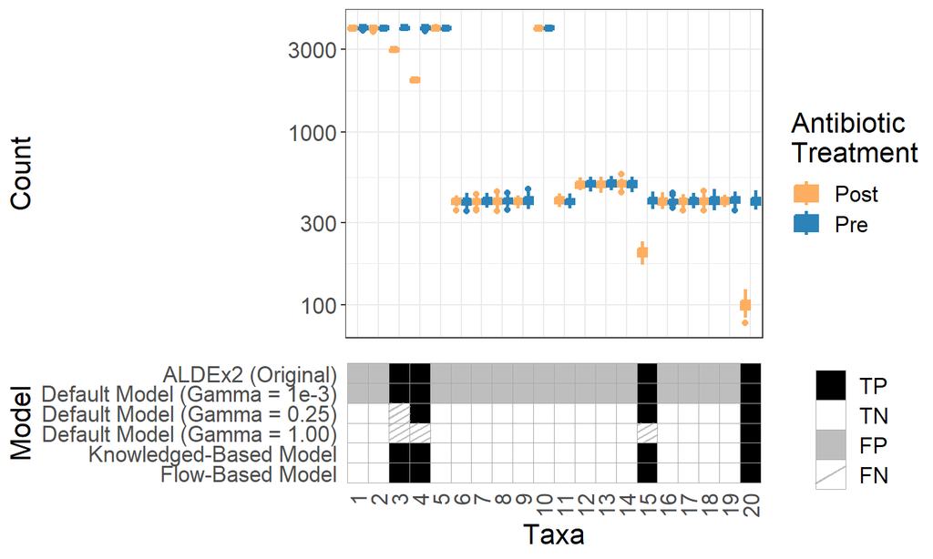

## Sensitivity Analyses

- How do we choose a value of \(\gamma\)?
- Why do we need to choose a value of \(\gamma\)?
- Sensitivity analyses circumvent this need and allow us to understand how an entity’s significance changes with varying amounts of scale noise.
- Several built-in functions help with this: `aldex.senAnalysis` and `plotGamma`.

## Sensitivity Analyses in ALDEx2

To run a sensitivity analysis in ALDEx2 using the default scale model, do the following:

1. Specify a vector of values of \(\gamma\) to test.
2. Run `aldex.clr` on the OTU table and conditions.
3. Run `aldex.senAnalysis` on the clr object and values of \(\gamma\).
4. (Optional) Use `plotGamma` to visualize results.

## Example: Sensitivity Analyses

```r
##Now running a sensitivity analysis over the default scale model

##First, specifying different values for the noise in the scale
gamma_to_test <- c(1e-3, .1, .25, .5, .75, 1, 2, 3, 4, 5)

##Run the CLR function
clr <- aldex.clr(Y, conds)

##Run sensitivity analysis function
sen_res <- aldex.senAnalysis(clr, gamma = gamma_to_test)

##Plotting the sensitivity results.
plotGamma(sen_res, thresh = .1)
```

## Example: Sensitivity Analyses, cont.

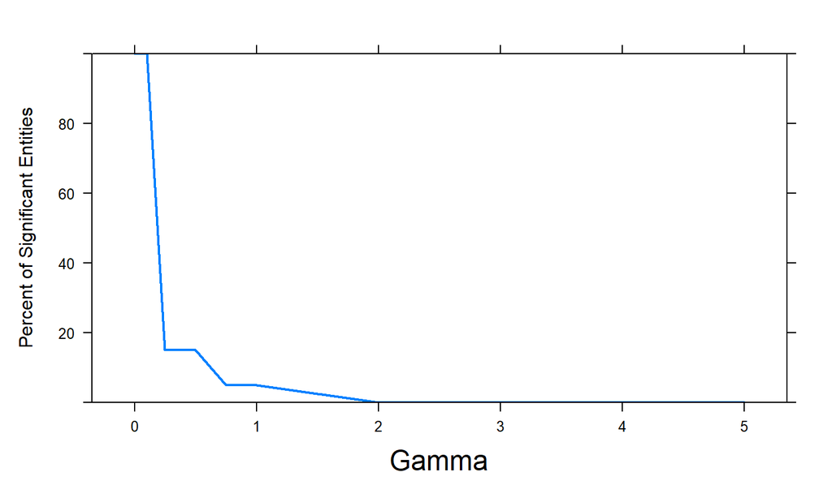

## Example: Sensitivity Analyses, cont.

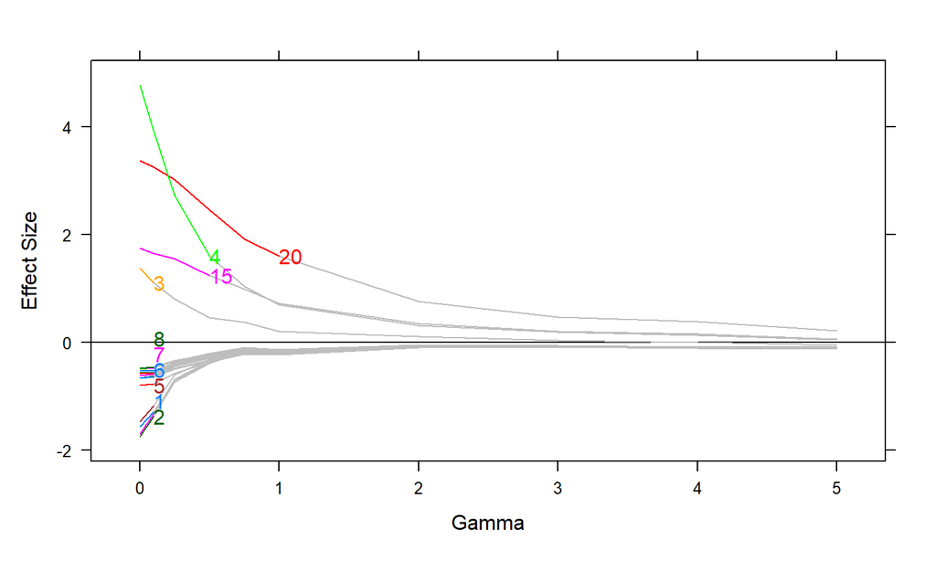

## A Real-Data Example with SELEX

## Data Description

- SELEX: Selected Growth Experiment.
- Goal is to determine which of 1,600 gene variants confer a growth phenotype.
- Study was conducted so that those variants that confer a growth phenotype would increase in the presence of a bacteriostatic toxin.
- Two conditions present: selected and non-selected.
  1. Selected: Bacteriostatic toxin allows for selected growth in some cell lines.
  2. Non-selected: Growth inhibitor leads to no growth in any of the cell lines.
- Originally published in McMurrough et. al (2014) and discussed in Fernandes et. al (2014).

## Reading in the Data

The ‘selex’ data is built-in to ‘ALDEx2’.

```r
library(ALDEx2)
library(tidyverse)
library(ggrepel)

conds <- c(rep("NS", 7), rep("S", 7))

data(selex)
selex[1:4,1:4]
```

```
##         X1_ANS X1_BNS X1_CNS X1_DNS
## A:D:A:D    347    271    396    317
## A:D:A:E    436    361    461    241
## A:E:A:D    476    288    378    215
## A:E:A:E    513    307    424    381
```

## We have access to ground truth data.

```r
##Ground truth
setwd('..')
true.pos <- read.delim(file.path("data","selex","selex-truth.txt"))$X
true.pos
```

```
##  [1] "A:E:G:E" "A:D:G:E" "A:E:G:D" "A:D:G:D" "G:E:A:E" "G:D:A:E" "G:E:A:D"
##  [8] "G:D:A:D" "A:E:A:E" "A:D:A:E" "A:E:A:D" "A:D:A:D" "G:E:G:E" "G:D:G:E"
## [15] "G:E:G:D" "G:D:G:D" "S:E:G:E" "S:D:G:E" "S:E:G:D" "S:D:G:D" "G:E:S:E"
## [22] "G:D:S:E" "G:E:S:D" "G:D:S:D" "A:E:S:E" "S:E:A:E" "S:E:S:E"
```

## Modeling with ALDEx2 (no scale)

```r
##ALDEx2
aldex.mod <- aldex(selex,conds)
aldex.pos <- aldex.mod %>% filter(we.eBH < 0.05)
table(row.names(aldex.pos) %in% true.pos)
```

```
##
## FALSE  TRUE
##    50    18
```

## Modeling with ALDEx2 (default scale)

```r
##Adding scale
aldex.scale <- aldex(selex, conds, gamma = .5)
aldex.scale.pos <- aldex.scale %>% filter(we.eBH < 0.05)
table(row.names(aldex.scale.pos) %in% true.pos)
```

```
##
## FALSE  TRUE
##    39    18
```

## Testing over Gamma (default scale)

```r
##Plotting TP and FP over different levels of gamma
gamma.to.test <- c(1e-3,.25,.5,.75,1,2,3, 4, 5)

TP <- rep(NA, length(gamma.to.test))
FP <- rep(NA, length(gamma.to.test))

for(i in 1:length(gamma.to.test)){
  mod <- aldex(selex,conds,gamma = gamma.to.test[i])
  mod.pos <- row.names(mod %>% filter(we.eBH < 0.05))

  TP[i] <- sum(mod.pos %in% true.pos)
  FP[i] <- sum(!(mod.pos %in% true.pos))
}
```

## Testing over Gamma (default scale), cont.

```r
graph.df <- data.frame("Gamma" = rep(gamma.to.test, 2), "Counts" = c(TP, FP), "Group" = c(rep("TP", length(gamma.to.test)), rep("FP", length(gamma.to.test))))

ggplot(graph.df, aes(x = Gamma, y = Counts, group = Group, color = Group)) +
  geom_line(aes(linetype = Group), lwd = 1.25) +
  scale_color_manual(values = c("red3", "royalblue3")) +
  scale_linetype_manual(values=c("twodash", "longdash")) +
  theme_bw() +
  ylab("Counts")
```

## Testing over Gamma (default scale), cont.

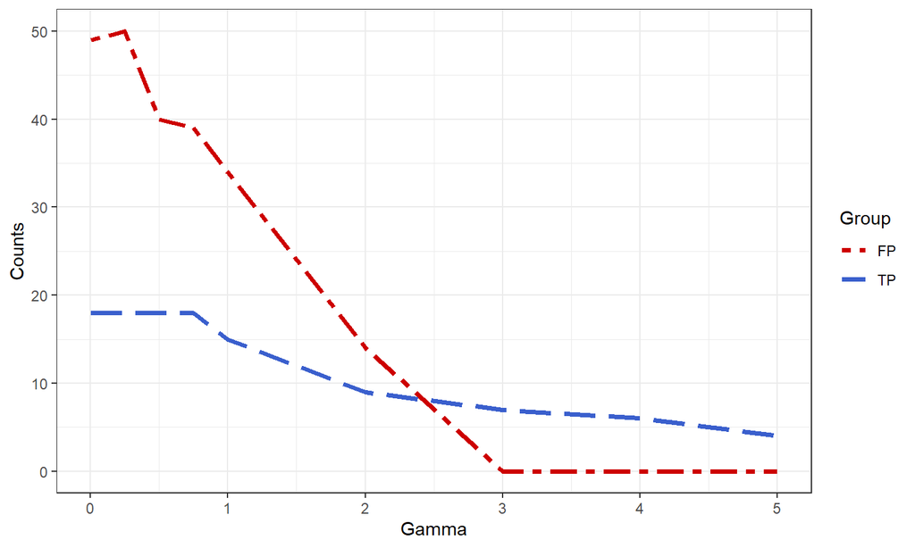

## Built-In Sensitivity Analyses

```r
##Built-in sensitivity analysis
clr <- aldex.clr(selex, conds)

##Run sensitivity analysis function
sen_res <- aldex.senAnalysis(clr, gamma = gamma.to.test)

##Plotting the sensitivity results.
plotGamma(sen_res, thresh = .1)
```

## Built-In Sensitivity Analyses, cont.

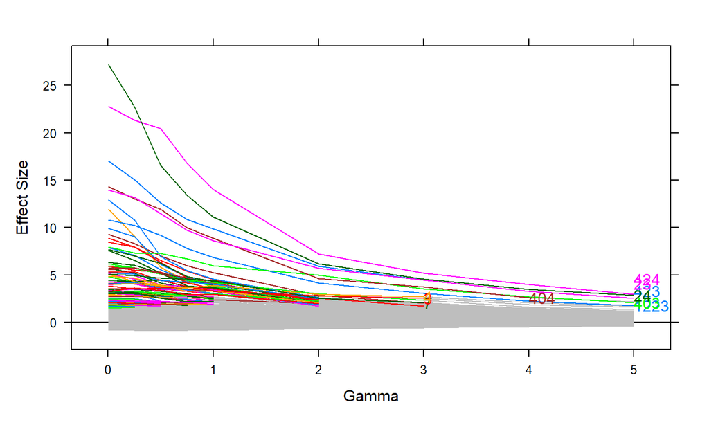

## References

- Nixon, et. al. (2023) “Scale Reliant Inference.” *ArXiv*.
- Gloor, Nixon, and Silverman. (2023) “Scale is Not What You Think; Explicit Scale Simulation in ALDEx2.” *BioRXiv*.
- Nixon, Gloor, and Silverman. (2023) “Beyond Normalizations: Incorporating Scale Uncertainty in ALDEx2.” *Forthcoming*.
- McMurrough et. al. (2014).”Control of catalytic efficiency by a coevolving network of catalytic and noncatalytic residues.” *PNAS*.
- Fernandes et. al. (2014). “Unifying the analysis of high-throughput sequencing datasets: characterizing RNA-seq, 16S rRNA gene sequencing and selective growth experiments by compositional data analysis.” *Microbiome*.